# AED

- Autor: **Juan Miguel Rodríguez Trujillo**
- Fecha: **Enero de 2025**

[figure not shown]

```python
from PIL import Image
import matplotlib.pyplot as plt
img = Image.open("Guía introductoria AED.png")
plt.figure(figsize=(10, 8))
plt.imshow(img)
plt.axis('off')
plt.show()
```

# Exploración inicial y limpieza

En esta sección aprenderemos sobre:

- **Librerías, carga y filtros**
- **Tratamiento de valores nulos y duplicados**
- **Exploración inicial de filas y columnas**
- **Estadísticas descriptivas para variables cuantitativas**
- **Frecuencia y valores únicos para variables cualitativas**

## Librerías, carga y filtros

En esta subsección **importamos las librerías** de interés `pandas`, `matplotlib`, `seaborn` y `numpy` para la manipulación y visualización de datos. **Cargamos el dataset** en formato `.csv` con la función `read_csv` de `pandas` y **filtramos las columnas** de interés.

```python
import numpy as np
import matplotlib.pyplot as plt
import pandas as pd
import seaborn as sns

import plotly.express as px
import plotly.graph_objects as go
from plotly.subplots import make_subplots
```

```python
# Carga inicial del .csv
df = pd.read_csv("saber11_2020.csv")

# Creamos un vector con el nombre de las columnas/variables que nos interesan
columnas_interes = [
    "COLE_NATURALEZA",
    "ESTU_DEDICACIONLECTURADIARIA",
    "FAMI_ESTRATOVIVIENDA",
    "FAMI_EDUCACIONPADRE",
    "FAMI_TIENEINTERNET",
    "FAMI_TIENECOMPUTADOR",
    "FAMI_NUMLIBROS",
    "PUNT_LECTURA_CRITICA",
    "PUNT_MATEMATICAS",
    "PUNT_C_NATURALES",
    "PUNT_SOCIALES_CIUDADANAS",
    "PUNT_INGLES",
    "PUNT_GLOBAL",
]

# Filtramos por columnas de interés
data = df[columnas_interes]
data = data[
    (data['FAMI_ESTRATOVIVIENDA'] != 'Sin Estrato')
]
```

## Tratamiento de valores nulos y duplicados

En esta subsección identificamos los **valores nulos y duplicados** mediante los métodos `isnull` y `duplicated` para después eliminarlos. **Es fundamental tener un dataset limpio y sin valores nulos para realizar una correcta visualización.**

```python
# Identificar valores nulos

print(" Conteo de valores nulos por columna: \n")
data.isnull().sum()
```

```
 Conteo de valores nulos por columna:
```

```
COLE_NATURALEZA                     0
ESTU_DEDICACIONLECTURADIARIA    14361
FAMI_ESTRATOVIVIENDA            16952
FAMI_EDUCACIONPADRE             12954
FAMI_TIENEINTERNET              13569
FAMI_TIENECOMPUTADOR            19805
FAMI_NUMLIBROS                  13747
PUNT_LECTURA_CRITICA                0
PUNT_MATEMATICAS                    0
PUNT_C_NATURALES                    0
PUNT_SOCIALES_CIUDADANAS            0
PUNT_INGLES                       229
PUNT_GLOBAL                         0
dtype: int64
```

```python
# Identificar valores duplicados

print("Número de filas duplicadas: \n")
print(data.duplicated().sum())
```

```
Número de filas duplicadas:

132
```

```python
# Eliminar filas con valores duplicados y nulos

def eliminar_nulos_duplicados(dataframe):
    dataframe = dataframe.drop_duplicates()
    dataframe = dataframe.dropna()
    print(f"Filas sin duplicados ni valores nulos: {dataframe.shape[0]}")
    return dataframe

data = eliminar_nulos_duplicados(data)
```

```
Filas sin duplicados ni valores nulos: 460287
```

## Exploración inicial de filas y columnas

En esta subsección **realizamos una observación inicial de los valores de las filas y columnas del dataset**, así como a sus **dimensiones** y al **tipo de variables** que interpreta Python. Esto mediante funciones y atributos como `info`, `shape` y `head`.

```python
# Información general del dataset

print("Información del dataset: \n")
data.info()

# Este códio imprime el nombre de las columnas del dataset, sus cantidad de valores
# "no nulos" y el tipo de variables.
# Donde:

# "object" hace referencia a una variable tipo texto (cualitativa)
# "int64" hace referencia a una variable numérica discreta (cuantitativa)
# "float64" hace referencia a una variable numércia continua (cuantitativa)
```

```
Información del dataset:

<class 'pandas.core.frame.DataFrame'>
Index: 460287 entries, 0 to 504871
Data columns (total 13 columns):
 #   Column                        Non-Null Count   Dtype
---  ------                        --------------   -----
 0   COLE_NATURALEZA               460287 non-null  object
 1   ESTU_DEDICACIONLECTURADIARIA  460287 non-null  object
 2   FAMI_ESTRATOVIVIENDA          460287 non-null  object
 3   FAMI_EDUCACIONPADRE           460287 non-null  object
 4   FAMI_TIENEINTERNET            460287 non-null  object
 5   FAMI_TIENECOMPUTADOR          460287 non-null  object
 6   FAMI_NUMLIBROS                460287 non-null  object
 7   PUNT_LECTURA_CRITICA          460287 non-null  int64
 8   PUNT_MATEMATICAS              460287 non-null  int64
 9   PUNT_C_NATURALES              460287 non-null  int64
 10  PUNT_SOCIALES_CIUDADANAS      460287 non-null  int64
 11  PUNT_INGLES                   460287 non-null  float64
 12  PUNT_GLOBAL                   460287 non-null  int64
dtypes: float64(1), int64(5), object(7)
memory usage: 49.2+ MB
```

```python
# Dimensiones del dataset

print(" Dimensiones del dataset: \n")
print(f"Filas: {data.shape[0]}, Columnas: {data.shape[1]}")
```

```
 Dimensiones del dataset:

Filas: 460287, Columnas: 13
```

```python
# Observación inicial de filas y columnas del dataset

print("Dataset filtrado con las columnas de interés: \n")
print(data.head())
```

```
Dataset filtrado con las columnas de interés:

  COLE_NATURALEZA ESTU_DEDICACIONLECTURADIARIA FAMI_ESTRATOVIVIENDA  \
0         OFICIAL           30 minutos o menos            Estrato 2
1         OFICIAL   No leo por entretenimiento            Estrato 3
2         OFICIAL        Entre 30 y 60 minutos            Estrato 1
4         OFICIAL            Entre 1 y 2 horas            Estrato 5
6      NO OFICIAL           30 minutos o menos            Estrato 3

                  FAMI_EDUCACIONPADRE FAMI_TIENEINTERNET FAMI_TIENECOMPUTADOR  \
0      Técnica o tecnológica completa                 Si                   Si
1  Secundaria (Bachillerato) completa                 Si                   No
2                 Primaria incompleta                 No                   No
4  Secundaria (Bachillerato) completa                 Si                   Si
6      Educación profesional completa                 Si                   Si

    FAMI_NUMLIBROS  PUNT_LECTURA_CRITICA  PUNT_MATEMATICAS  PUNT_C_NATURALES  \
0  26 A 100 LIBROS                    54                65                41
1    0 A 10 LIBROS                    57                43                46
2    0 A 10 LIBROS                    59                72                63
4    0 A 10 LIBROS                    37                48                44
6  26 A 100 LIBROS                    49                68                50

   PUNT_SOCIALES_CIUDADANAS  PUNT_INGLES  PUNT_GLOBAL
0                        33         55.0          244
1                        49         33.0          238
2                        68         59.0          325
4                        32         43.0          202
6                        51         65.0          277
```

```python
# También el dataset se puede visualizar en formato datafream

data.head()
```

|  | COLE_NATURALEZA | ESTU_DEDICACIONLECTURADIARIA | FAMI_ESTRATOVIVIENDA | FAMI_EDUCACIONPADRE | FAMI_TIENEINTERNET | FAMI_TIENECOMPUTADOR | FAMI_NUMLIBROS | PUNT_LECTURA_CRITICA | PUNT_MATEMATICAS | PUNT_C_NATURALES | PUNT_SOCIALES_CIUDADANAS | PUNT_INGLES | PUNT_GLOBAL |
| --- | --- | --- | --- | --- | --- | --- | --- | --- | --- | --- | --- | --- | --- |
| 0 | OFICIAL | 30 minutos o menos | Estrato 2 | Técnica o tecnológica completa | Si | Si | 26 A 100 LIBROS | 54 | 65 | 41 | 33 | 55.0 | 244 |
| 1 | OFICIAL | No leo por entretenimiento | Estrato 3 | Secundaria (Bachillerato) completa | Si | No | 0 A 10 LIBROS | 57 | 43 | 46 | 49 | 33.0 | 238 |
| 2 | OFICIAL | Entre 30 y 60 minutos | Estrato 1 | Primaria incompleta | No | No | 0 A 10 LIBROS | 59 | 72 | 63 | 68 | 59.0 | 325 |
| 4 | OFICIAL | Entre 1 y 2 horas | Estrato 5 | Secundaria (Bachillerato) completa | Si | Si | 0 A 10 LIBROS | 37 | 48 | 44 | 32 | 43.0 | 202 |
| 6 | NO OFICIAL | 30 minutos o menos | Estrato 3 | Educación profesional completa | Si | Si | 26 A 100 LIBROS | 49 | 68 | 50 | 51 | 65.0 | 277 |

## Estadísticas descriptivas para variables cuantitativas

Esta subsección nos permite conocer de manera rápida y sencilla las principales **estadísticas descriptivas de las variables cuantitativas**, aquellas tipo `int64` y `float64`, mediante el método `describe`.

```python
print("Estadísticas descriptivas para variables numéricas: \n")

numeric_columns = data.select_dtypes(include=['float64', 'int64'])
numeric_columns.describe()
```

```
Estadísticas descriptivas para variables numéricas:
```

|  | PUNT_LECTURA_CRITICA | PUNT_MATEMATICAS | PUNT_C_NATURALES | PUNT_SOCIALES_CIUDADANAS | PUNT_INGLES | PUNT_GLOBAL |
| --- | --- | --- | --- | --- | --- | --- |
| count | 460287.000000 | 460287.000000 | 460287.000000 | 460287.000000 | 460287.000000 | 460287.000000 |
| mean | 52.545892 | 51.476103 | 48.650362 | 48.658639 | 47.346551 | 250.515320 |
| std | 9.999261 | 11.514633 | 10.369718 | 11.900292 | 11.156963 | 48.090145 |
| min | 0.000000 | 0.000000 | 0.000000 | 0.000000 | 0.000000 | 0.000000 |
| 25% | 45.000000 | 43.000000 | 41.000000 | 39.000000 | 39.000000 | 214.000000 |
| 50% | 53.000000 | 51.000000 | 48.000000 | 48.000000 | 45.000000 | 247.000000 |
| 75% | 60.000000 | 59.000000 | 56.000000 | 57.000000 | 53.000000 | 284.000000 |
| max | 100.000000 | 100.000000 | 100.000000 | 100.000000 | 100.000000 | 500.000000 |

## Frecuencia y valores únicos para variables cualitativas

El código de esta subsección nos permite identificar la **frecuencia y valores únicos que toman las variables cualitativas**, aquellas tipo `object`. Esto mediante métodos como `value_counts`.

```python
print("Frecuencia y valores únicos por variable cualitativa: \n")
object_columns = data.select_dtypes(include=['object'])

for col in object_columns.columns:
    print(f"\nVariable: {col}")
    print(data[col].value_counts())
```

```
Frecuencia y valores únicos por variable cualitativa:


Variable: COLE_NATURALEZA
COLE_NATURALEZA
OFICIAL       354624
NO OFICIAL    105663
Name: count, dtype: int64

Variable: ESTU_DEDICACIONLECTURADIARIA
ESTU_DEDICACIONLECTURADIARIA
30 minutos o menos            177515
Entre 30 y 60 minutos         124807
No leo por entretenimiento     90035
Entre 1 y 2 horas              47674
Más de 2 horas                 20256
Name: count, dtype: int64

Variable: FAMI_ESTRATOVIVIENDA
FAMI_ESTRATOVIVIENDA
Estrato 2    177969
Estrato 1    148683
Estrato 3    101097
Estrato 4     22836
Estrato 5      6761
Estrato 6      2941
Name: count, dtype: int64

Variable: FAMI_EDUCACIONPADRE
FAMI_EDUCACIONPADRE
Secundaria (Bachillerato) completa      113722
Primaria incompleta                      84631
Secundaria (Bachillerato) incompleta     61118
Educación profesional completa           44682
Primaria completa                        42631
Técnica o tecnológica completa           31860
No sabe                                  27978
Ninguno                                  17842
Educación profesional incompleta          9727
Técnica o tecnológica incompleta          9623
```

[output cut: 8 more lines]

```
Name: count, dtype: int64

Variable: FAMI_TIENECOMPUTADOR
FAMI_TIENECOMPUTADOR
Si    284401
No    175886
Name: count, dtype: int64

Variable: FAMI_NUMLIBROS
FAMI_NUMLIBROS
0 A 10 LIBROS        190791
11 A 25 LIBROS       143460
26 A 100 LIBROS       96207
MÁS DE 100 LIBROS     29829
Name: count, dtype: int64
```

# Visualización de datos

En esta sección aprenderemos sobre:

**1. Visualización individual de variables cuantitativas**

**2. Visualización conjunta de variables cuantitativas**

**3. Visualización individual de variables cualitativas**

**4. Visualización conjunta de variables cualitativas**

**5. Visualización conjunta de variables cuantitativas y cualitativas**

## Visualización individual de variables cuantitativas

En esta subsección introduciremos los **conceptos y tipos de gráficos más comunes para la visualización individual de una variable cuantitativa.**

Aprenderemos sobre:

**1. Histograma**

**2. Diagrama de caja y bigotes (Box-Plot)**

**3. Gráfico de violín (Violin-Plot)**

**4. Gráfico de densidad (Kernel Density-Plot)**

```python
# Creamos vectores que almacenan variables cuantitativas específicas y de interés para visualizar más adelante

quantitative_vars = data[['PUNT_GLOBAL', 'PUNT_MATEMATICAS', 'PUNT_C_NATURALES', 'PUNT_INGLES', 'PUNT_SOCIALES_CIUDADANAS', 'PUNT_LECTURA_CRITICA' ]]
quantitative_vars_1 = data[['PUNT_GLOBAL', 'PUNT_MATEMATICAS', 'PUNT_C_NATURALES']]
quantitative_vars_2 = data[['PUNT_INGLES', 'PUNT_SOCIALES_CIUDADANAS', 'PUNT_LECTURA_CRITICA']]
```

### Histograma

**Un histograma es un gráfico de barras que muestra la distribución de un conjunto de datos en rangos o segmentos**. La altura de cada barra representa la frecuencia con la que aparece la variable en cada rango. Es ideal para visualizar la forma de la distribución, la centralidad y la dispersión.

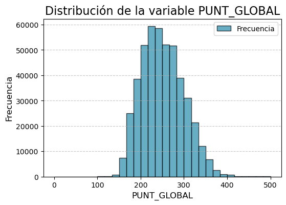

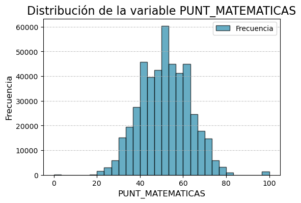

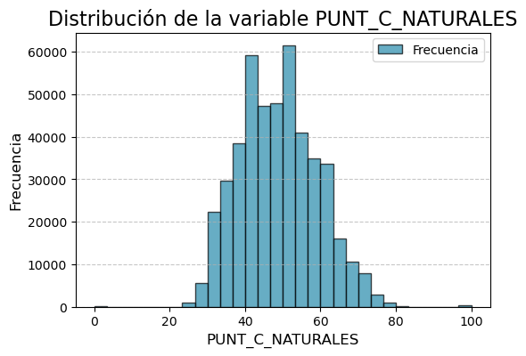

```python
for var in quantitative_vars_1:
    plt.figure(figsize=(6, 4))

    # Histograma
    plt.hist(data[var], bins=30, alpha=0.7, color="#268AAB", edgecolor='black',
             label='Frecuencia')
    # Configuración del gráfico
    plt.title(f'Distribución de la variable {var}', fontsize=16)
    plt.xlabel(var, fontsize=12)
    plt.ylabel('Frecuencia', fontsize=12)
    plt.legend(loc='best')
    plt.grid(axis='y', linestyle='--', alpha=0.7)
    plt.show()
```

### Diagrama de caja y bigotes (Box-Plot)

**Un Box-Plot muestra la distribución de un conjunto de datos a través de sus cuartiles, mínimos, máximos y datos atípicos**. Permite identificar valores atípicos y comparar distribuciones.

**1.** Los límites de la caja son el $Q_1$ (25%) y el $Q_3$ (75%).

**2.** La línea dentro de la caja es el dato de la mitad, mediana o $Q2$ (50%).

**3.** Los límites inferior y superior de los bigotes son:

- Límite Inferior = $Q_1 - 1.5 \cdot RIC$
- Límite Superior = $Q_3 + 1.5 \cdot RIC$

Donde $RIC$ se define como **Rango Interquartílico** y se calcula como la diferencia entre el $Q_3$ y $Q_1$:

- $RIC = Q_3 - Q_1$

**Aquellos datos que se encuentran por fueral del Límite Inferior\Superior son considerados datos atípicos**

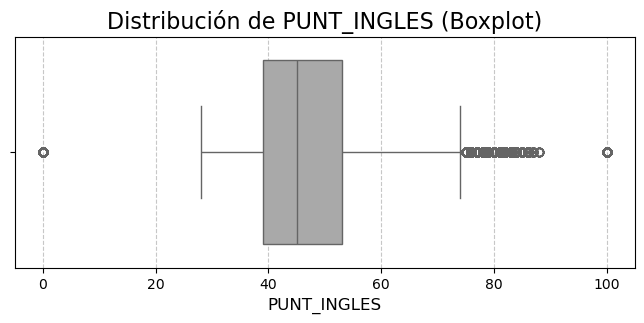

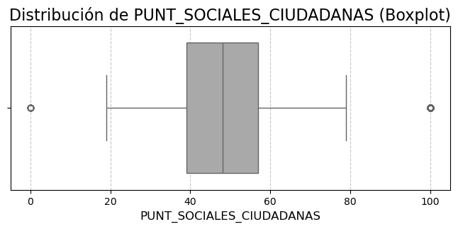

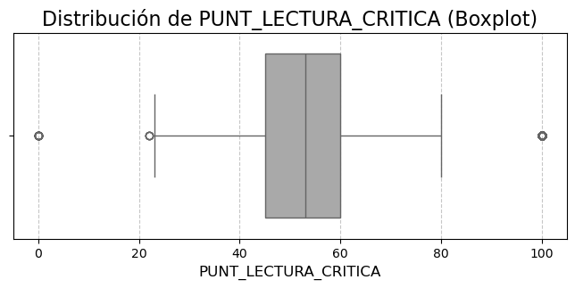

```python
for var in quantitative_vars_2:
    plt.figure(figsize=(6, 4))

# Boxplot
    plt.figure(figsize=(8, 3))
    sns.boxplot(x=data[var], color="#A9A9A9")
    plt.title(f'Distribución de {var} (Boxplot)', fontsize=16)
    plt.xlabel(var, fontsize=12)
    plt.grid(axis='x', linestyle='--', alpha=0.7)
    plt.show()
```

### Gráfico de violín (Violin-Plot)

**Un gráfico de violín combina las herramientas del Box-Plot y del Gráfico de densidad. En su interior, contiene:**

- Dos rectángulos pequeños que reflejan el $Q_1$ y $Q_3$.
- En el espacio entre estos dos rectángulos se encuentra la mediana $Q_2$.
- La alutra/ancho del violín representa la frecuencia/densidad de datos en torno a su valor en el eje x.

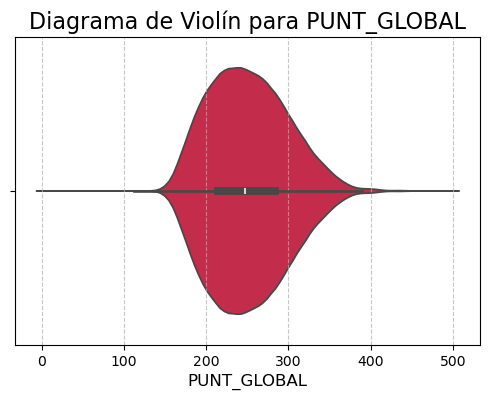

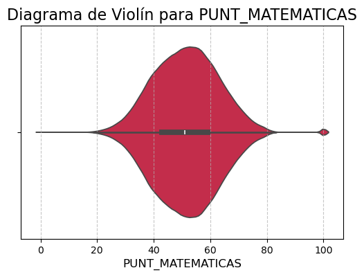

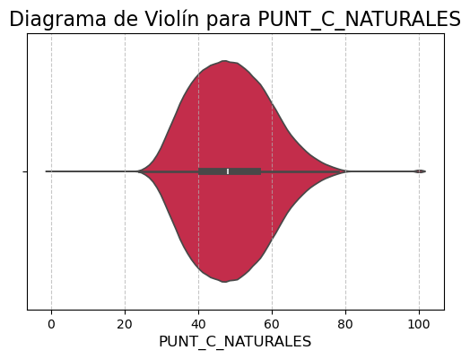

```python
for var in quantitative_vars_1:
    plt.figure(figsize=(6, 4))
    sns.violinplot(x=data[var], color="#DC143C")
    plt.title(f'Diagrama de Violín para {var}', fontsize=16)
    plt.xlabel(var, fontsize=12)
    plt.grid(axis='x', linestyle='--', alpha=0.7)
    plt.show()
```

### Gráfico de densidad (Kernel Density-Plot)

Un **gráfico de densidad suaviza la distribución de las variables cuantitaivas** representadas inicalmente en el histograma. A pesar de que se pierde información detallada de cada variable, **es útil para hacer análisis entre variables que presenten una misma unidad de medida y similar rango.**

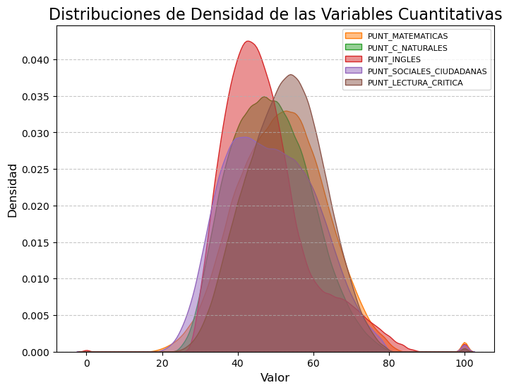

```python
# Gráfico de densidad combinado para todas las variables cuantitativas (sin incluir 'PUNT_GLOBAL')
plt.figure(figsize=(8, 6))

# Paleta de colores para identificar las variables fácilmente
colors = sns.color_palette('tab10', len(quantitative_vars))

for i, var in enumerate(quantitative_vars):
    if var != 'PUNT_GLOBAL':
        sns.kdeplot(data[var], fill=True, alpha=0.5, label=var, color=colors[i])

# Configuración del gráfico
plt.title('Distribuciones de Densidad de las Variables Cuantitativas', fontsize=16)
plt.xlabel('Valor', fontsize=12)
plt.ylabel('Densidad', fontsize=12)
plt.legend(loc='best', fontsize=8)  # Tamaño más pequeño para la leyenda
plt.grid(axis='y', linestyle='--', alpha=0.7)
plt.show()
```

## Visualización conjunta de variables cuantitativas

En esta subsección introduciremos los **conceptos y tipos de gráficos más comunes para la visualización conjunta variables cuantitativas.**

Aprenderemos sobre:

**1. Gráfico de dispersión (Scatter-Plot)**

**2. Matriz de correlación (Heatmap)**

**3. Gráfico de pares (Pair-Plot)**

```python
# Para los gráficos de dispersion rreamos una muestra aleatoria de 1000 observaciones para aquellos
# estudiantes pertenecientes al estrato 5. Esto es útil para los gráficos de dispersión, pues no
# se recomienda para una gran cantidad de observaciones.

f_data = data[data['FAMI_ESTRATOVIVIENDA'].isin(['Estrato 5'])]
f_data_sample = f_data.sample(n=1000)
```

### Gráfico de dispersión (Scatter-Plot)

**Un Gráfico de dispersión o Scatter-Plot muestra la ubicación de una observación en un plano mediante los valores que toma para las dos variables cuantitativas de interés**

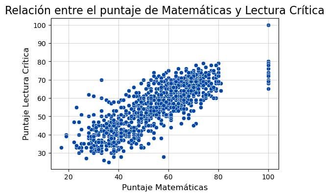

```python
#Scatter-Plot
plt.figure(figsize = (6,4))
sns.scatterplot(x=f_data_sample['PUNT_MATEMATICAS'], y=f_data_sample['PUNT_LECTURA_CRITICA'], color="#0047AB")
plt.title('Relación entre el puntaje de Matemáticas y Lectura Crítica', fontsize=16)
plt.xlabel('Puntaje Matemáticas', fontsize=12)
plt.ylabel('Puntaje Lectura Crítica', fontsize=12)
plt.grid(alpha=0.5)
plt.show()
```

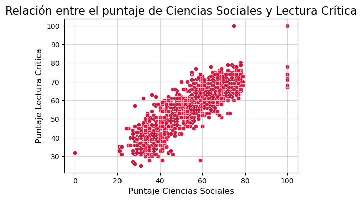

```python
plt.figure(figsize = (6,4))
sns.scatterplot(x=f_data_sample['PUNT_SOCIALES_CIUDADANAS'], y=f_data_sample['PUNT_LECTURA_CRITICA'], color="#DC143C")
plt.title('Relación entre el puntaje de Ciencias Sociales y Lectura Crítica', fontsize=16)
plt.xlabel('Puntaje Ciencias Sociales', fontsize=12)
plt.ylabel('Puntaje Lectura Crítica', fontsize=12)
plt.grid(alpha=0.5)
plt.show()
```

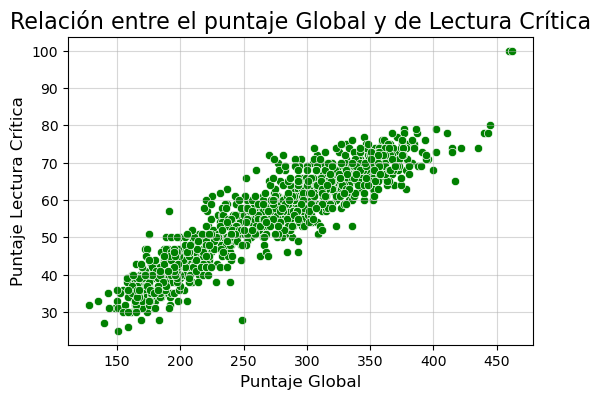

```python
plt.figure(figsize = (6,4))
sns.scatterplot(x=f_data_sample['PUNT_GLOBAL'], y=f_data_sample['PUNT_LECTURA_CRITICA'], color="Green")
plt.title('Relación entre el puntaje Global y de Lectura Crítica', fontsize=16)
plt.xlabel('Puntaje Global', fontsize=12)
plt.ylabel('Puntaje Lectura Crítica', fontsize=12)
plt.grid(alpha=0.5)
plt.show()
```

### Matriz de correlación (Heatmap)

**Una matriz de correlación es una tabla que muestra los coeficientes de correlación entre todas las variables numéricas de un conjunto de datos.** Cada celda de la tabla representa el coeficiente de correlación entre dos variables específicas. Los coeficientes de correlación varían entre -1 y 1, donde:

- Si el valor es cercano a +1, se acepta una fuerte correlación positiva
- Si el valor es cercano a -1, se acepta una fuerte Correlación negativa
- Si el valor es cercano a 0, se acepta una débil o nula correlación

La fórmula del coeficiente de correlación es:

$ corr(x,y) = \frac{\sum_{i=1}^{n}(x_i - \bar{x})(y_i - \bar{y})}{\sqrt{\sum_{i=1}^{n}(x_i - \bar{x})^2}\sqrt{\sum_{i=1}^{n}(y_i - \bar{y})^2}}$

$\begin{aligned} \text{Donde:} \\ x_i & : \text{El valor individual de la variable } x. \\ y_i & : \text{El valor individual de la variable } y. \\ \bar{x} & : \text{La media aritmética de la variable } x. \\ \bar{y} & : \text{La media aritmética de la variable } y. \\ n & : \text{El número total de observaciones.} \\ \sum_{i=1}^n & : \text{La suma de los valores desde } i=1 \text{ hasta } i=n. \\ \sqrt{} & : \text{La raíz cuadrada.} \end{aligned}$

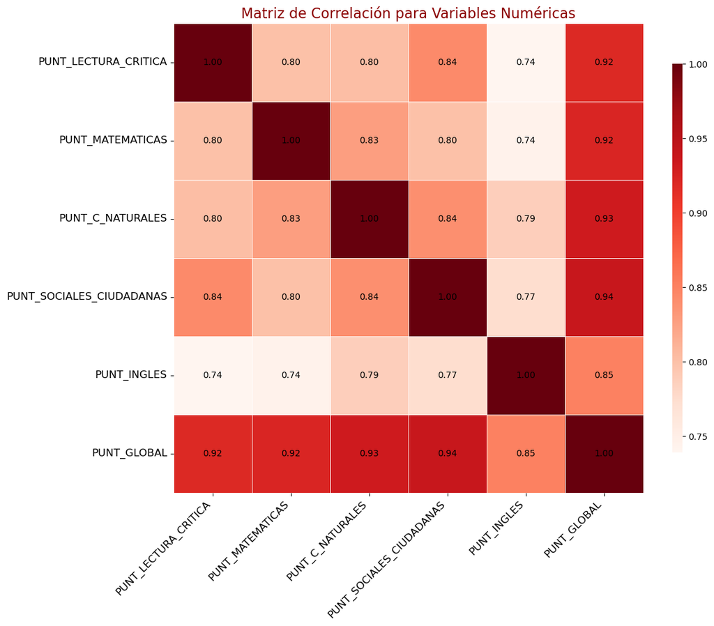

```python
# Seleccionar únicamente variables de tipo float64 e int64
f_numeric_data = f_data.select_dtypes(include=['float64', 'int64'])

plt.figure(figsize=(12, 10))  # Tamaño más amplio
corr_matrix = f_numeric_data.corr()
sns.heatmap(
    corr_matrix,
    annot=True,
    fmt='.2f',
    cmap='Reds',
    square=True,
    linewidths=0.5,  # Líneas entre celdas
    cbar_kws={'shrink': 0.8, 'aspect': 40},  # Barra de color ajustada
    annot_kws={'size': 10, 'color': 'black'}  # Sin negrilla en las anotaciones
)
plt.title('Matriz de Correlación para Variables Numéricas', fontsize=16, color='darkred')
plt.xticks(fontsize=12, rotation=45, ha='right')  # Rotación y estilo de etiquetas del eje x
plt.yticks(fontsize=12)  # Estilo de etiquetas del eje y
plt.show()
```

### Gráfico de pares (Pair-Plot)

**Un pairplot te permite visualizar de manera rápida y general las relaciones entre múltiples variables numéricas.** Combina **gráficos de dispersión (scatter plots)** y **gráficos de densidad (KDE plots)** para mostrar relaciones entre múltiples variables cuantitativas.

- La diagonal de la matriz muestra la distribución univariada para cada variable.
- Los demás elementos de la matriz exponen los gráficos de dispersión para las variables de su respectiva fila y columna.
- La matriz se podría llegar a considerar en cierto sentido simétrica, pues las variables de sus ejes son las mismas.

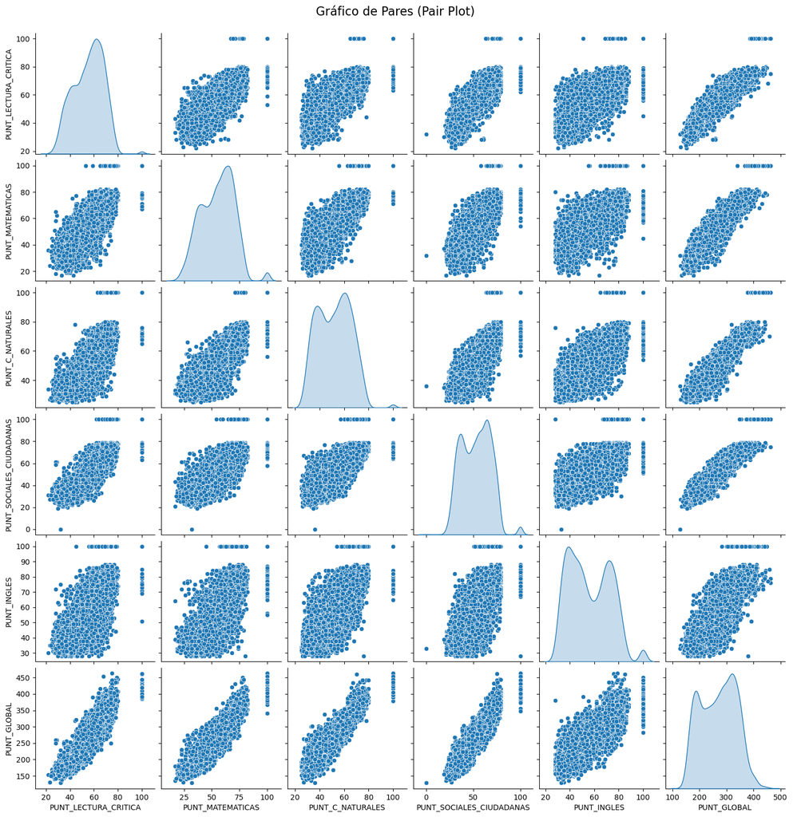

```python
sns.pairplot(data=f_numeric_data, diag_kind='kde', corner=False)
plt.suptitle('Gráfico de Pares (Pair Plot)', y=1.02, fontsize=16)
plt.show()

# Este gráfico sí se realizó con los datos poblaciones de los estudiantes de viviendas estrato 5.
# No con una muestra de esta población.
```

## Visualización individual de variables cualitativas

En esta subsección introduciremos los **conceptos y tipos de gráficos más comunes para la visualización individual de una variable cualitativa.**

Aprenderemos sobre:

**1. Gráfico de barras (Bar-Plot)**

**2. Gráfico de pastel (Pie-Chart)**

### Gráfico de barras (Bar-Plot)

**Un gráfico de barras o Bar-Plot muestra la frecuencia de las distintas categorías que toma una variable cualitativa.**

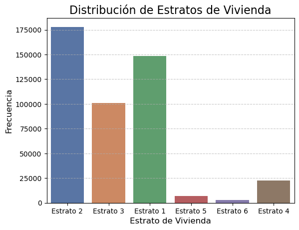

```python
sns.countplot(x=data['FAMI_ESTRATOVIVIENDA'], palette='deep',  hue=data['FAMI_ESTRATOVIVIENDA'])
plt.title('Distribución de Estratos de Vivienda', fontsize=16)
plt.xlabel('Estrato de Vivienda', fontsize=12)
plt.ylabel('Frecuencia', fontsize=12)
plt.grid(axis='y', linestyle='--', alpha=0.7)
plt.show()
```

### Gráfico de pastel (Pie-chart)

**Un gráfico de pastel o Pie-Chart muestra la proporción de cada categoría como un sector del círculo.**

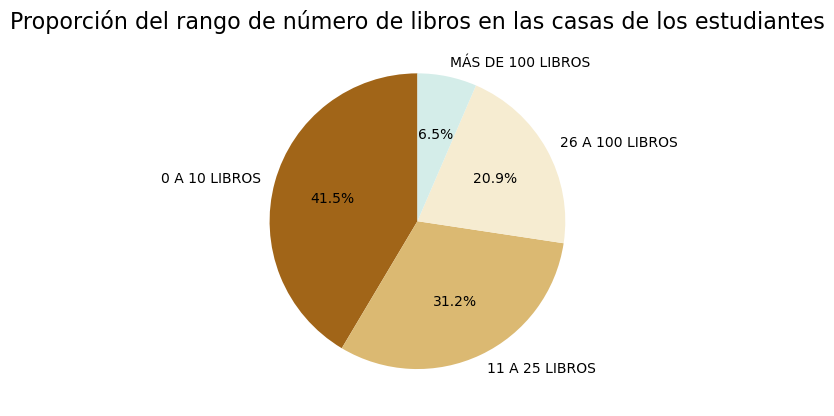

```python
data['FAMI_NUMLIBROS'].value_counts().plot.pie(
    autopct='%1.1f%%', startangle=90, colors=sns.color_palette("BrBG"))
plt.title('Proporción del rango de número de libros en las casas de los estudiantes', fontsize=16)
plt.ylabel('')
plt.show()
```

### Gráfico de dona (Donut-Chart)

**Similar al gráfico de pastel, pero con un círculo vacío en medio.**

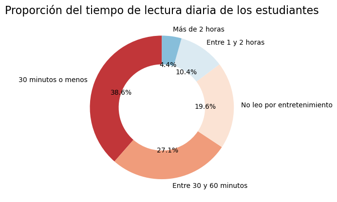

```python
counts = data['ESTU_DEDICACIONLECTURADIARIA'].value_counts()
plt.pie(counts, labels=counts.index, autopct='%1.1f%%', startangle=90, colors=sns.color_palette("RdBu"), wedgeprops=dict(width=0.4))
plt.title('Proporción del tiempo de lectura diaria de los estudiantes', fontsize=16)
plt.show()
```

### Tabla de frecuencia absoluta y relativa

**Una tabla de frecuencia absoluta y relativa muestra estas medidas para las categorías de una variable cualitativa.**

```python
freq_table = data['FAMI_ESTRATOVIVIENDA'].value_counts().reset_index()
freq_table.columns = ['Categoría', 'Frecuencia']
freq_table['Proporción (%)'] = round( freq_table['Frecuencia'] / freq_table['Frecuencia'].sum() * 100 , 2)

freq_table
```

|  | Categoría | Frecuencia | Proporción (%) |
| --- | --- | --- | --- |
| 0 | Estrato 2 | 177969 | 38.66 |
| 1 | Estrato 1 | 148683 | 32.30 |
| 2 | Estrato 3 | 101097 | 21.96 |
| 3 | Estrato 4 | 22836 | 4.96 |
| 4 | Estrato 5 | 6761 | 1.47 |
| 5 | Estrato 6 | 2941 | 0.64 |

## Visualización conjunta de variables cualitativas

En esta subsección introduciremos los **conceptos y tipos de gráficos más comunes para la visualización conjunta de variables cualitativas.**

Aprenderemos sobre:

**1. Tablas dinámicas**

**2. Gráfico de barras apilado**

**3. Gráfico de barras agrupado**

### Tablas dinámicas

**Las tablas dinámicas son herramientas esenciales para osbervar la frecuencia relativa y/o absoluta (y cualquier otra medida) entre la intersección de las distintas categorías de dos variables cualitativas.**

```python
cross_tab_totales = pd.crosstab(
    data['FAMI_TIENEINTERNET'],
    data['FAMI_ESTRATOVIVIENDA'],
    margins=True,
    margins_name="Total"
)

cross_tab_totales
```

| FAMI_ESTRATOVIVIENDA FAMI_TIENEINTERNET | Estrato 1 | Estrato 2 | Estrato 3 | Estrato 4 | Estrato 5 | Estrato 6 | Total |
| --- | --- | --- | --- | --- | --- | --- | --- |
| No | 75871 | 41334 | 10847 | 2404 | 1072 | 716 | 132244 |
| Si | 72812 | 136635 | 90250 | 20432 | 5689 | 2225 | 328043 |
| Total | 148683 | 177969 | 101097 | 22836 | 6761 | 2941 | 460287 |

**También se pueden visualizar las participaciones de cada combinación de categoría**

```python
cross_tab_relative = pd.crosstab(
    data['FAMI_NUMLIBROS'],
    data['ESTU_DEDICACIONLECTURADIARIA'],
    normalize='index'  # Proporción por fila
)
cross_tab_relative['Total'] = cross_tab_relative.sum(axis=1)

cross_tab_relative
```

| ESTU_DEDICACIONLECTURADIARIA FAMI_NUMLIBROS | 30 minutos o menos | Entre 1 y 2 horas | Entre 30 y 60 minutos | Más de 2 horas | No leo por entretenimiento | Total |
| --- | --- | --- | --- | --- | --- | --- |
| 0 A 10 LIBROS | 0.438385 | 0.074448 | 0.218019 | 0.028298 | 0.240850 | 1.0 |
| 11 A 25 LIBROS | 0.381870 | 0.102858 | 0.302509 | 0.039091 | 0.173672 | 1.0 |
| 26 A 100 LIBROS | 0.322139 | 0.141331 | 0.320195 | 0.062948 | 0.153388 | 1.0 |
| MÁS DE 100 LIBROS | 0.271548 | 0.171544 | 0.301988 | 0.107043 | 0.147876 | 1.0 |

**También se pueden ver las tablas dinámicas como un "heatmap"**

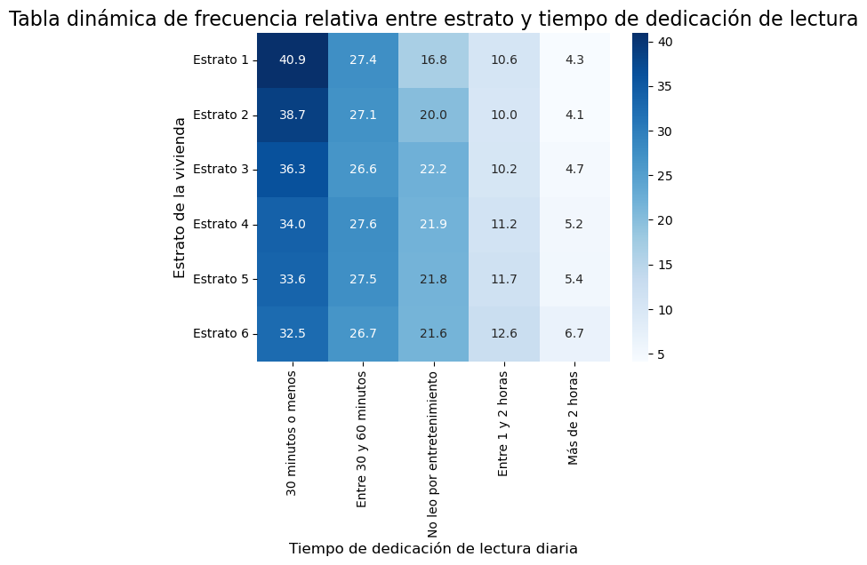

```python
# Crear la tabla cruzada
cross_tab = pd.crosstab(data['FAMI_ESTRATOVIVIENDA'], data['ESTU_DEDICACIONLECTURADIARIA'])

# Calcular las frecuencias relativas por fila (porcentaje de cada estrato)
cross_tab_pct = cross_tab.div(cross_tab.sum(axis=1), axis=0) * 100

# Obtener el orden de las categorías de lectura según su participación en el Estrato 1
orden_categorias = cross_tab_pct.loc['Estrato 1'].sort_values(ascending=False).index

# Reordenar los niveles del índice de columnas
cross_tab_pct = cross_tab_pct.reindex(columns=orden_categorias)

# Crear el heatmap con las columnas reordenadas
sns.heatmap(cross_tab_pct, annot=True, cmap='Blues', fmt='.1f')
plt.title('Tabla dinámica de frecuencia relativa entre estrato y tiempo de dedicación de lectura', fontsize=16)
plt.xlabel('Tiempo de dedicación de lectura diaria', fontsize=12)
plt.ylabel('Estrato de la vivienda', fontsize=12)
plt.show()
```

### Gráfico de barras apilado

**Un gráfico de barras que apila una variable dentro de otra para mostrar frecuencias y proporciones.**

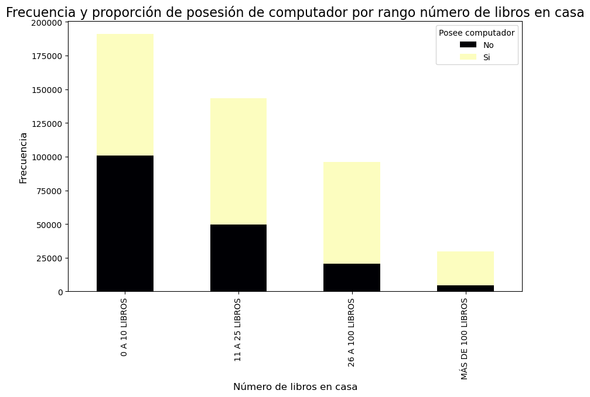

```python
cross_tab = pd.crosstab(data['FAMI_NUMLIBROS'], data['FAMI_TIENECOMPUTADOR'])
cross_tab.plot(kind='bar', stacked=True, colormap='magma', figsize=(10, 6))
plt.title('Frecuencia y proporción de posesión de computador por rango número de libros en casa', fontsize=16)
plt.xlabel('Número de libros en casa', fontsize=12)
plt.ylabel('Frecuencia', fontsize=12)
plt.legend(title='Posee computador', fontsize=10)
plt.show()
```

### Gráfico de barras agrupado

**Similar al gráfico de barras apilado, pero muestra las categorías lado a lado.**

[figure not shown]

```python
cross_tab = pd.crosstab(data['FAMI_ESTRATOVIVIENDA'], data['FAMI_NUMLIBROS'])
cross_tab.plot(kind='bar', colormap='coolwarm', figsize=(10, 6))
plt.title('Relación entre Estrato de la vivienda y número de libros', fontsize=16)
plt.xlabel('Naturaleza del Colegio', fontsize=12)
plt.ylabel('Frecuencia', fontsize=12)
plt.legend(title='Número de libros', fontsize=10)
plt.show()
```

## Visualización conjunta de variables cualitativas y cuantitativas

**En esta subsección se hará una introducción sobre los principales métodos de visualización para variables cuantitativas y cualitativas en conjunto. Entre las principales herramientas se encuentran:**

**1. Bar-Plot con promedio y desviación estándar por categoría**

**2. Box-Plot por categoría**

**3. Histogramas agrupados por categoría**

```python
import warnings
warnings.filterwarnings("ignore")
# Filtrar el DataFrame para eliminar categorías específicas en 'FAMI_EDUCACIONPADRE'

data_1 = data[~data['FAMI_EDUCACIONPADRE'].isin(['No Aplica', 'No sabe'])]
```

### Bar-Plot con promedio y desviación estándar por categoría

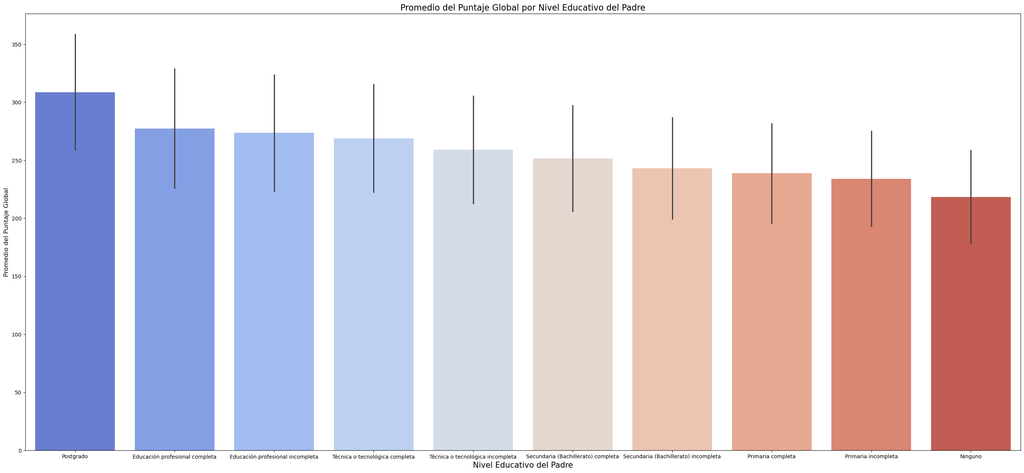

```python
# Calcular los promedios para ordenar las categorías
order = data_1.groupby('FAMI_EDUCACIONPADRE')['PUNT_GLOBAL'].mean().sort_values(ascending=False).index

# Crear el gráfico de barras ordenado
plt.figure(figsize=(34, 15))
sns.barplot(
    x=data_1['FAMI_EDUCACIONPADRE'],
    y=data_1['PUNT_GLOBAL'],
    errorbar='sd',
    palette='coolwarm',
    order=order  # Ordenar las barras por el promedio
)

# Personalización del gráfico
plt.title('Promedio del Puntaje Global por Nivel Educativo del Padre', fontsize=16)
plt.xlabel('Nivel Educativo del Padre', fontsize=15)
plt.ylabel('Promedio del Puntaje Global', fontsize=12)
plt.show()
```

### Box-Plot por categoría

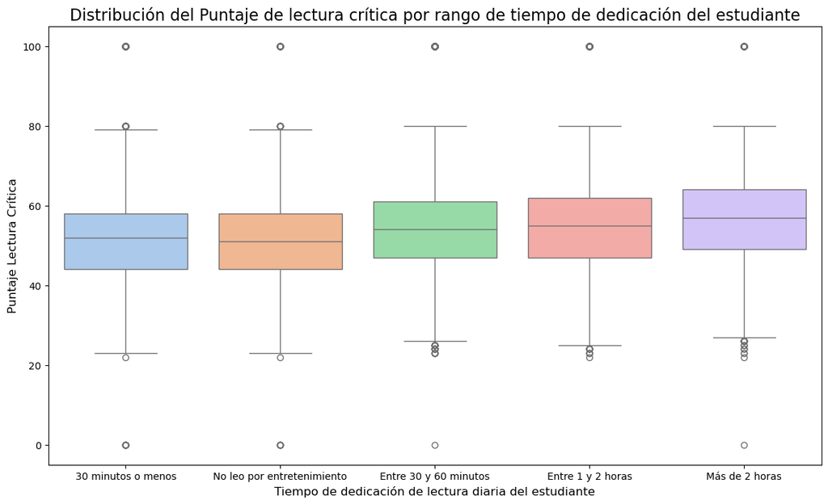

```python
plt.figure(figsize=(14, 8))
sns.boxplot(x=data['ESTU_DEDICACIONLECTURADIARIA'], y=data['PUNT_LECTURA_CRITICA'], palette='pastel')
plt.title('Distribución del Puntaje de lectura crítica por rango de tiempo de dedicación del estudiante', fontsize=16)
plt.xlabel('Tiempo de dedicación de lectura diaria del estudiante', fontsize=12)
plt.ylabel('Puntaje Lectura Crítica', fontsize=12)
plt.show()
```

### Histogramas agrupados por categoría

[figure not shown]

```python
# Crear histogramas agrupados sin KDE y ajustar el eje Y para el puntaje global
plt.figure(figsize=(8, 6))  # Ajustar tamaño del gráfico

for categoria in data['FAMI_TIENEINTERNET'].unique():
    subset = data[data['FAMI_TIENEINTERNET'] == categoria]
    sns.histplot(
        subset['PUNT_MATEMATICAS'],
        label=categoria,
        alpha=0.6,
        bins=25  # Ajustar número de barras
    )

# Personalización del gráfico
plt.title('Distribución del Puntaje de Matemáticas por tenencia de servicios de internet', fontsize=16)
plt.xlabel('Puntaje Global', fontsize=12)
plt.ylabel('Frecuencia', fontsize=12)
plt.legend(title='Carácter', fontsize=10)
plt.grid(axis='y', linestyle='--', alpha=0.7)  # Añadir líneas de referencia en el eje Y
plt.show()
```

### Swarm-Plot

**Un Swarm-Plot es un tipo de gráfico de visualización de datos que te permite observar la distribución de un conjunto de datos numéricos, categorizados por una variable categórica.**

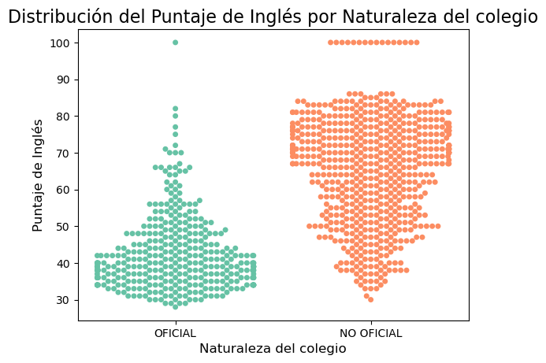

```python
sns.swarmplot(x=f_data_sample['COLE_NATURALEZA'], y=f_data_sample['PUNT_INGLES'], palette='Set2')
plt.title('Distribución del Puntaje de Inglés por Naturaleza del colegio', fontsize=16)
plt.xlabel('Naturaleza del colegio', fontsize=12)
plt.ylabel('Puntaje de Inglés', fontsize=12)
plt.show()
```